# Deforestation

DSA2101 Project

2024-04-14

# 1 Introduction

The deforestation data set provides vital information about deforestation trends around the world, as well as a data set specifically about Brazil. This data is from [*Our World in Data*](https://ourworldindata.org/forests-and-deforestation), comprising of 5 CSV files. Breaking down these CSV files:

1. `forest.csv` shows the change in forest area every 5 years.
2. `forest_area.csv` shows the change in forest area as a percentage of the global forest area.
3. `brazil_loss.csv` shows the loss of Brazil’s forests due to various reasons such as pasture and commercial use.
4. `soybean_use.csv` shows the use and production of soybeans by country and year (annually).
5. `vegetable_oil.csv` shows the trend of vegetable oil production y year and country.

Our group aims to identify the country with the most extensive forest destruction and the highest deforestation rates across the years. Additionally, we intend to discover the underlying causes behind the high deforestation rates in that country.

Our group is interested in this question as we recognise the important role that forests play in our ecosystem. They act as the lungs of the earth, absorbing carbon dioxide and reducing heat trapped in the atmosphere *(Nunez, 2022)*, thus lowering global temperature. They also provide habitats for indigenous people and a diverse range of wildlife species. *(World Wildlife fund, 2022)*. Without them, air temperatures increase, contributing to global warming, and wildlife and indigenous people lose their homes. Analyzing the main contributors and causes of deforestation allows stakeholders and relevant agencies to intervene and take necessary actions.

To address this question, we will start off by using the forest dataset with the “net_forest_conversion” variable, indicating whether forest area has increased or decreased in five-year intervals. Using this data, we will generate a world map to illustrate the extent of forest destruction, thus identifying the country with the highest total forest area destroyed till 2010.

# 2 Data cleaning and visualization

## 2.1 Importing libraries

```r
library(readr)
#install.packages("tidytuesdayR")
library(tidyverse)
#install.packages("maps")
library(maps)
library(scales)
library(ggthemes)
```

## 2.2 Importing dataset

```r
forest <- readr::read_csv('https://raw.githubusercontent.com/rfordatascience/tidytuesday/master/data/2021/2021-04-06/forest.csv')
forest_area <- readr::read_csv('https://raw.githubusercontent.com/rfordatascience/tidytuesday/master/data/2021/2021-04-06/forest_area.csv')
brazil_loss <- readr::read_csv('https://raw.githubusercontent.com/rfordatascience/tidytuesday/master/data/2021/2021-04-06/brazil_loss.csv')
soybean_use <- readr::read_csv('https://raw.githubusercontent.com/rfordatascience/tidytuesday/master/data/2021/2021-04-06/soybean_use.csv')
vegetable_oil <- readr::read_csv('https://raw.githubusercontent.com/rfordatascience/tidytuesday/master/data/2021/2021-04-06/vegetable_oil.csv')
```

## 2.3 First visualisation

### 2.3.1 Data cleaning for `forest.csv`

```r
forest_chng = forest %>%
  filter(year >= 2005, year <= 2010, entity != "World", code != "NA") %>%
  group_by(entity) %>%
  summarise(net_forest_conversion = sum(net_forest_conversion)) %>%
  ungroup() %>%
  filter(net_forest_conversion <0) %>%
  arrange(desc(net_forest_conversion)) %>%
  slice_min(net_forest_conversion, n = 5)
```

### 2.3.2 Plotting first visualisation

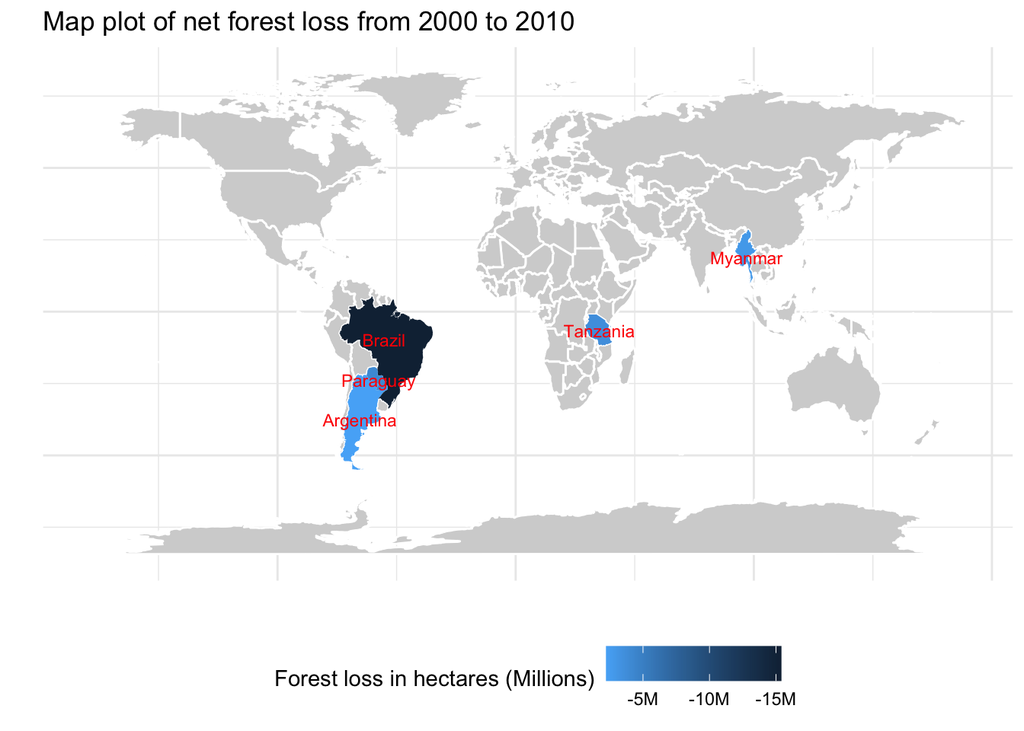

```r
# Retrieve the top 5 entities with highest net forest loss from 2000 to 2010
top5 = forest_chng %>%
  pull(entity)

# Inserting world data
world = map_data("world")

# Data cleaning for world
world = world %>%
  select(-subregion)
forest_chng_world = left_join(forest_chng, world, by = c("entity" = "region")) %>%
  na.omit()

# get mean latitude and longitude for top 5 entities
top5_lat_long <- forest_chng_world[,c("entity", "long","lat")]

top5_lat_long <- top5_lat_long %>%
  group_by(entity)%>%
  summarize(avg_long = mean(long, na.rm = TRUE),
            avg_lat = mean(lat, na.rm = TRUE))

# Visualization of world map with deforestation
ggplot(data = world, aes(x = long, y = lat, group = group)) +
  geom_polygon(fill = "lightgrey", color = "white") +
  geom_polygon(data = forest_chng_world, aes(fill = net_forest_conversion)) +
  geom_text(data = top5_lat_long, color="red", size = 3, aes(x = avg_long, y = avg_lat, label = entity, group = NULL)) + # Text label for top 5
  theme_minimal() +
  theme(legend.position = "bottom", axis.ticks = element_blank(), axis.text = element_blank()) +
  labs(x = "", y = "", fill = "Forest loss in hectares (Millions)") +
  ggtitle("Map plot of net forest loss from 2000 to 2010")+
  scale_fill_continuous(labels=c('-15M', '-10M', '-5M','0M')) + # change the legend title for better readability
  guides(fill = guide_colorbar(reverse=TRUE)) # flip the legend around to order from lowest net forest loss to highest net forest loss
```

The world map plot illustrates the net forest loss from 2000 to 2010, using a gradient where lighter shades of blue indicate less net forest loss and darker shades represent greater loss. Brazil appears to have the darkest shades of blue, indicating the highest net forest loss in hectares compared to other countries.

A map plot was chosen as it allows us to immediately spot and identify any obvious outliers. Since our first visualisation aims to only spot outliers, we reserve the information gathering abilities of other plots for identifying causes and trends when drilling down into Brazil.

## 2.4 Second visualisation

### 2.4.1 Data cleaning for `brazil_loss.csv`

```r
brazil_long = brazil_loss %>%
  select(-code, -entity)
brazil_long = pivot_longer(brazil_long, cols = -year, names_to = "Loss_type", values_to = "Losses")
```

### 2.4.2 Plotting second visualisation

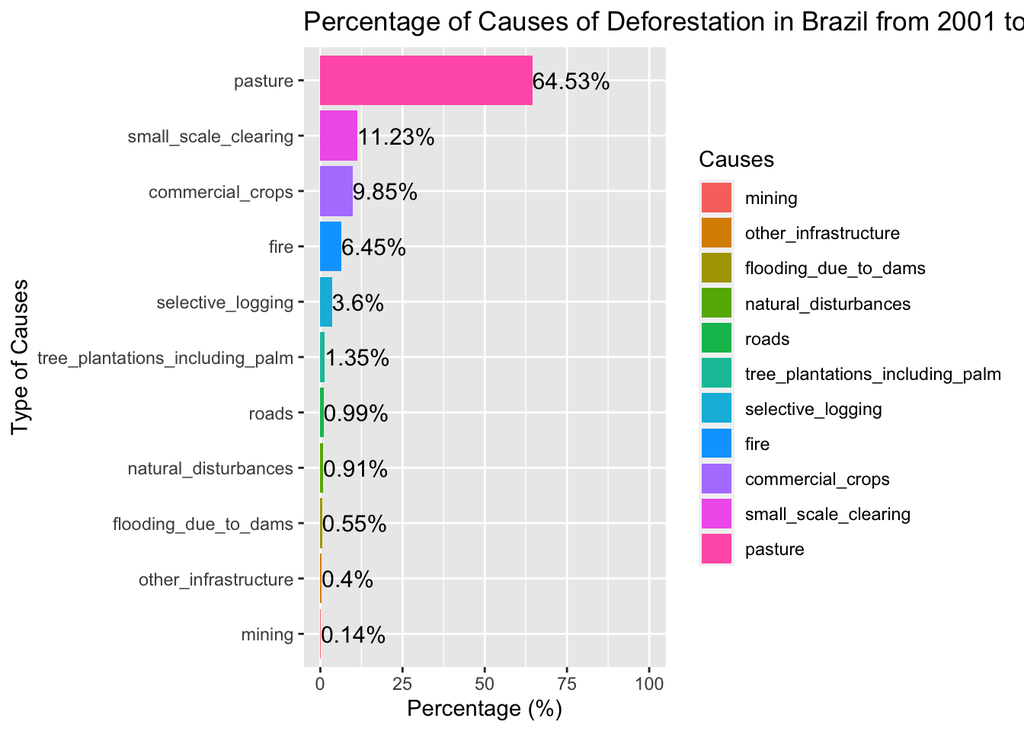

```r
# Calculating the total percentage of land damaged by different causes from yr 2001-2010
Causes_in_Brazil = brazil_long %>%
  filter(year <= 2010) %>%
  group_by(Loss_type) %>%
  summarize(total = sum(Losses)) %>%
  mutate(pct = total/sum(total)*100,
         pct = round(pct, 2)) %>%
  arrange(desc(pct)) %>%
  mutate(Loss_type = reorder(Loss_type, pct)) %>%
  rename(Causes = Loss_type)


# Visualisation of brazil_loss
ggplot(data = Causes_in_Brazil) +
  geom_col(aes(x = Causes, y = pct, fill = Causes), size = 0.95) +
  ggtitle("Percentage of Causes of Deforestation in Brazil from 2001 to 2010") +
  labs(y = "Percentage (%)", x = "Type of Causes") +
  geom_text(aes(x = Causes, y = pct, label = paste0(pct, "%")),
            hjust = 0, size = 4, color = "black") +
  scale_color_discrete() +
  ylim(0,100) +
  coord_flip()
```

## 2.5 Third visualisation

### 2.5.1 Data cleaning for `vegetable_oil.csv`

```r
vegetable_oil_clean = vegetable_oil %>% # Change all NA values to 0   .
  mutate(production = coalesce(production, 0))
# Pivot wider to combine production values of all categories into 1 .
vegetable_oil_wide = pivot_wider(vegetable_oil, id_cols = "entity", names_from = "year", values_from = "production")
# Revert back to long data .
vegetable_oil_long <- pivot_longer(vegetable_oil_wide, cols = -entity, names_to = "year", values_to = "production") %>%
  mutate(production = sapply(production, sum)) %>%
  mutate(year = as.double(year)) %>%
  rename(vege_oil_production_tonnes = production)
```

### 2.5.2 Plotting third visualisation

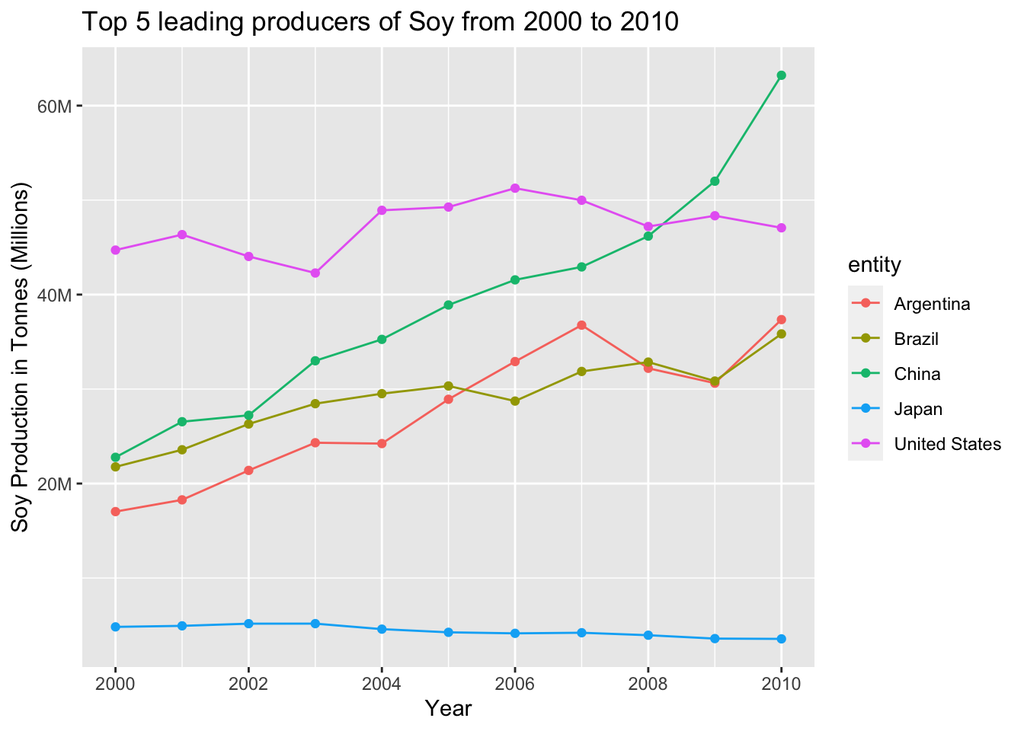

```r
soy_vege = inner_join(soybean_use, vegetable_oil_long) %>%
  mutate(soy_production_tonnes = human_food + animal_feed + processed) %>%
  filter(code != "NA", entity != "World") %>%
  filter(year > 1999, year < 2011) %>%
  mutate(across(everything(), ~ifelse(is.na(.), 0, .)))

soy_vege_total = soy_vege %>%
  group_by(entity) %>%
  summarise(vege_oil_production_tonnes = sum(vege_oil_production_tonnes),
            soy_production_tonnes = sum(soy_production_tonnes)) %>%
  ungroup() %>%
  arrange(desc(soy_production_tonnes)) %>%
  slice_max(soy_production_tonnes, n = 5) %>%
  pull(entity)

soy_vege_top_5 = soy_vege %>%
  filter(entity %in% soy_vege_total)

ggplot(soy_vege_top_5, aes(x = year, y = soy_production_tonnes, color = entity)) +
  geom_line()  +
  geom_point() +
  scale_color_discrete() +
 labs(x = "Year", y = "Soy Production in Tonnes (Millions)",
     title = "Top 5 leading producers of Soy from 2000 to 2010") +
  scale_x_continuous(breaks = seq(2000, 2010, by = 2)) + # Setting breaks to show axis with intervals of 2 years
  scale_y_continuous(labels=c('0M', '20M', '40M', '60M')) # Changing the x-axis labels to millions for better readability
```

# 3 Discussion

# 4 Reference

# 5 About

This project was developed for *DSA2101 Essential Data Analytics Tools: Data Visualization* at the National University of Singapore (NUS). The team is comprised of the following members:

| Name | Year | Major | Responsibilities |
| --- | --- | --- | --- |
| Xiao Xuan | 2 | Data Science and Analytics |  |
| Nodoka | 2 | Data Science and Analytics |  |
| Jia Yi | 2 | Data Science and Analytics |  |
| Ryan | 2 | Data Science and Analytics |  |
| Min Yi | 2 | Psychology |  |